# Clustering and classification

A new week, a new section! This week is about clustering the data. As per usual, here are the libraries I’m using.

```r
# Used knitr options: No "##" before output
library(dplyr)
library(ggplot2)
library(GGally)
library(gridExtra)
library(reshape2)
library(tidyr)
library(MASS)  # Contains the used dataset
library(corrplot)
set.seed(2020)
```

## Data description

Unlike previous weeks, this week we are using a dataset that we have not wrangled with before! The data is the `Boston` dataset that is available in R package called `MASS`. Below is a table that lists the columns in the dataset. Full disclosure, I lifted the descriptions directly from R documentation (accessible by typing `?Boston` in R console).

| Column | Description |
| --- | --- |
| crim | per capita crime rate by town. |
| zn | proportion of residential land zoned for lots over 25,000 sq.ft. |
| indus | proportion of non-retail business acres per town. |
| chas | Charles River dummy variable (= 1 if tract bounds river; 0 otherwise). |
| nox | nitrogen oxides concentration (parts per 10 million). |
| rm | average number of rooms per dwelling. |
| age | proportion of owner-occupied units built prior to 1940. |
| dis | weighted mean of distances to five Boston employment centres. |
| rad | index of accessibility to radial highways. |
| tax | full-value property-tax rate per $10,000. |
| ptratio | pupil-teacher ratio by town. |
| black | *1000(Bk - 0.63)^2* where *Bk* is the proportion of blacks by town. |
| lstat | lower status of the population (percent). |
| medv | median value of owner-occupied homes in $1000s. |

The data is titled as *Housing Values in Suburbs of Boston*. The dataset contains 14 variables and 506 rows. All columns are numerical, although the variable `chas` is actually a boolean indicator represented as ones and zeros. Also as per usual, here are the outputs for `str`, `head` and `summary` functions for the `Boston` dataset:

```r
data("Boston")  # Creates variable named Boston
str(Boston)
```

```
'data.frame':   506 obs. of  14 variables:
 $ crim   : num  0.00632 0.02731 0.02729 0.03237 0.06905 ...
 $ zn     : num  18 0 0 0 0 0 12.5 12.5 12.5 12.5 ...
 $ indus  : num  2.31 7.07 7.07 2.18 2.18 2.18 7.87 7.87 7.87 7.87 ...
 $ chas   : int  0 0 0 0 0 0 0 0 0 0 ...
 $ nox    : num  0.538 0.469 0.469 0.458 0.458 0.458 0.524 0.524 0.524 0.524 ...
 $ rm     : num  6.58 6.42 7.18 7 7.15 ...
 $ age    : num  65.2 78.9 61.1 45.8 54.2 58.7 66.6 96.1 100 85.9 ...
 $ dis    : num  4.09 4.97 4.97 6.06 6.06 ...
 $ rad    : int  1 2 2 3 3 3 5 5 5 5 ...
 $ tax    : num  296 242 242 222 222 222 311 311 311 311 ...
 $ ptratio: num  15.3 17.8 17.8 18.7 18.7 18.7 15.2 15.2 15.2 15.2 ...
 $ black  : num  397 397 393 395 397 ...
 $ lstat  : num  4.98 9.14 4.03 2.94 5.33 ...
 $ medv   : num  24 21.6 34.7 33.4 36.2 28.7 22.9 27.1 16.5 18.9 ...
```

```r
knitr::kable(head(Boston, 5))
```

| crim | zn | indus | chas | nox | rm | age | dis | rad | tax | ptratio | black | lstat | medv |
| --- | --- | --- | --- | --- | --- | --- | --- | --- | --- | --- | --- | --- | --- |
| 0.00632 | 18 | 2.31 | 0 | 0.538 | 6.575 | 65.2 | 4.0900 | 1 | 296 | 15.3 | 396.90 | 4.98 | 24.0 |
| 0.02731 | 0 | 7.07 | 0 | 0.469 | 6.421 | 78.9 | 4.9671 | 2 | 242 | 17.8 | 396.90 | 9.14 | 21.6 |
| 0.02729 | 0 | 7.07 | 0 | 0.469 | 7.185 | 61.1 | 4.9671 | 2 | 242 | 17.8 | 392.83 | 4.03 | 34.7 |
| 0.03237 | 0 | 2.18 | 0 | 0.458 | 6.998 | 45.8 | 6.0622 | 3 | 222 | 18.7 | 394.63 | 2.94 | 33.4 |
| 0.06905 | 0 | 2.18 | 0 | 0.458 | 7.147 | 54.2 | 6.0622 | 3 | 222 | 18.7 | 396.90 | 5.33 | 36.2 |

```r
summary(Boston)
```

```
      crim                zn             indus            chas
 Min.   : 0.00632   Min.   :  0.00   Min.   : 0.46   Min.   :0.00000
 1st Qu.: 0.08205   1st Qu.:  0.00   1st Qu.: 5.19   1st Qu.:0.00000
 Median : 0.25651   Median :  0.00   Median : 9.69   Median :0.00000
 Mean   : 3.61352   Mean   : 11.36   Mean   :11.14   Mean   :0.06917
 3rd Qu.: 3.67708   3rd Qu.: 12.50   3rd Qu.:18.10   3rd Qu.:0.00000
 Max.   :88.97620   Max.   :100.00   Max.   :27.74   Max.   :1.00000
      nox               rm             age              dis
 Min.   :0.3850   Min.   :3.561   Min.   :  2.90   Min.   : 1.130
 1st Qu.:0.4490   1st Qu.:5.886   1st Qu.: 45.02   1st Qu.: 2.100
 Median :0.5380   Median :6.208   Median : 77.50   Median : 3.207
 Mean   :0.5547   Mean   :6.285   Mean   : 68.57   Mean   : 3.795
 3rd Qu.:0.6240   3rd Qu.:6.623   3rd Qu.: 94.08   3rd Qu.: 5.188
 Max.   :0.8710   Max.   :8.780   Max.   :100.00   Max.   :12.127
      rad              tax           ptratio          black
 Min.   : 1.000   Min.   :187.0   Min.   :12.60   Min.   :  0.32
 1st Qu.: 4.000   1st Qu.:279.0   1st Qu.:17.40   1st Qu.:375.38
 Median : 5.000   Median :330.0   Median :19.05   Median :391.44
 Mean   : 9.549   Mean   :408.2   Mean   :18.46   Mean   :356.67
 3rd Qu.:24.000   3rd Qu.:666.0   3rd Qu.:20.20   3rd Qu.:396.23
 Max.   :24.000   Max.   :711.0   Max.   :22.00   Max.   :396.90
     lstat            medv
 Min.   : 1.73   Min.   : 5.00
 1st Qu.: 6.95   1st Qu.:17.02
 Median :11.36   Median :21.20
 Mean   :12.65   Mean   :22.53
 3rd Qu.:16.95   3rd Qu.:25.00
 Max.   :37.97   Max.   :50.00
```

Looking at the summary, there are a couple of notable elements visible. First, the `crim` (*per capita crime rate by town*) variable is under 4 for most of the rows, but the maximum is *88.98*, almost three magnitudes larger than the median value (0.26)! The high discrepancy could be explained by the town in question having a low number of people, however the data doesn’t include this value. The variable `zn` (*proportion of residential land zoned for lots over 25000 sq.ft.*) exhibits similar behavior: minimum and median values are both 0 and maximum value is 100. This tells that most of the towns have no residential lots over 25000 sq.ft. in size. Similarly for variable `chas`, which simply denotes which areas are connected to Charles River and which not. Data states that at least 75% of the data is not connected to the river. For drawing more insight from the rest of the data, let’s plot a couple of pictures.

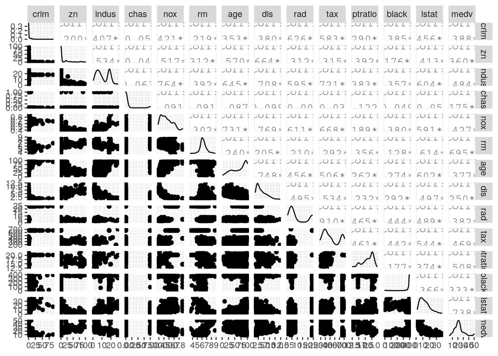

```r
ggpairs(Boston)
```

Okay, so, the `ggpairs` plot out-of-the-box isn’t the most clearest presentation. Let’s try some alternatives… First, let’s take a look at the density plots for each variable. (I finally figured out how to do this, thanks StackOverflow! Yay, go me.) The only variable resembling a normal distribution is `rm`, which is *average number of rooms per dwelling*. Okay, makes sense as it is an average value. Variables `indus`, `rad` and `tax` show two peaks, meaning that there are more towns with “low” and “high” values than “middle” values. The populace seems to be elderly, as the density increases (almost monotonically) as `age` gets larger. Variables `nox`, `dis`, `lstat` and `medv` are positively skewed and `ptratio` is negatively skewed.

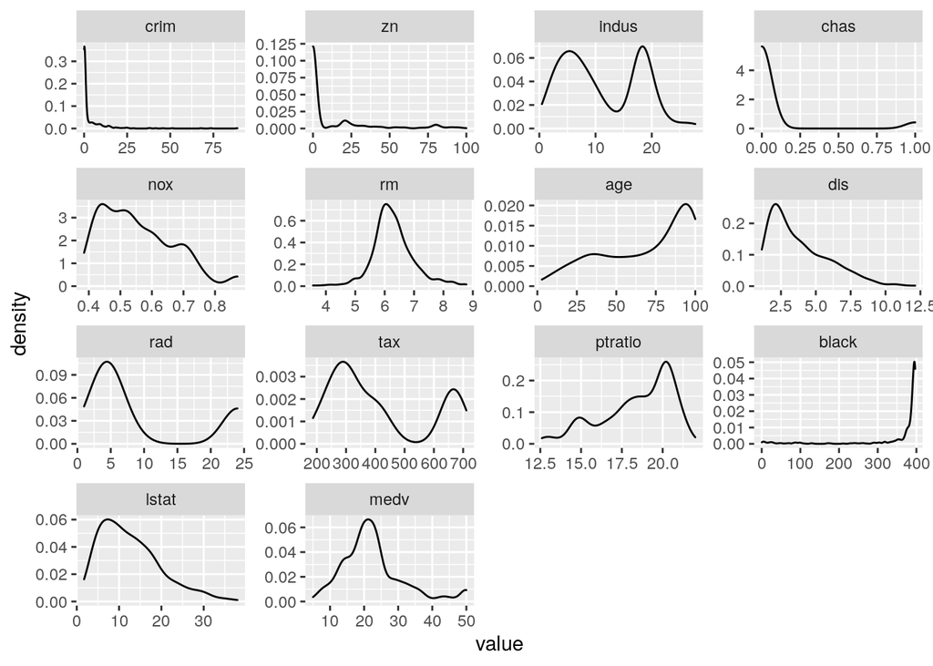

```r
longtable <- melt(Boston)
ggplot(longtable, aes(value)) + geom_density() + facet_wrap(~variable, scales="free")
```

Interestingly, the variable `black` looks like a mirrored version of `crim`. It’s a derived value related to the proportion of black people. I don’t know how the original dataset authors derived the function ($1000\left(Bk - 0.63\right)^2$), but the density graph shows that most of the towns have a proportion of black people that deviates from value 0.63. Plotting the function shows that when its value is over 375.38 (i.e. 1st quantile), the proportion of black people is under 0.02.

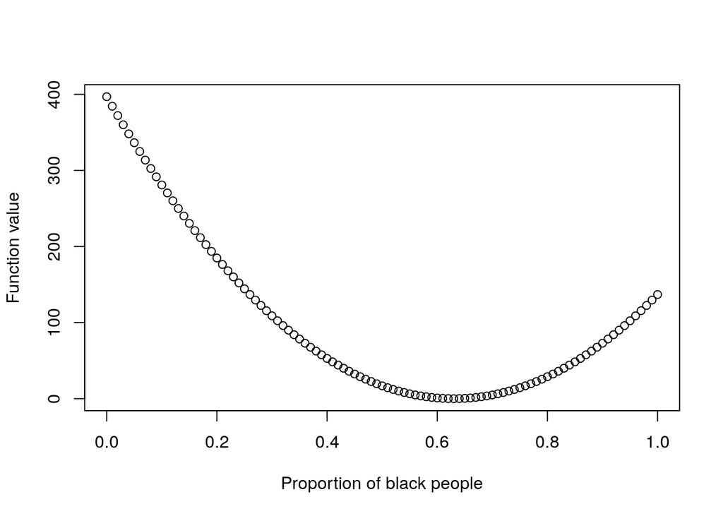

```r
x <- 0:100 / 100
y <- 1000*(x-0.63)^2
plot(x,y, xlab="Proportion of black people", ylab="Function value")
```

```r
# Show the values of x when y > 375.38 (i.e. the value of 1st quantile)
x[y > 375.38]
```

```
[1] 0.00 0.01
```

Finally, let’s plot the correlation between all variables using the fancy `corrplot` function from the `corrplot` library. From the picture, looks like `rad` and `tax` are strongly correlated (positive). That implies that the towns closer to more highways also tax their people more. Other notable correlations are `indus`, `nox` and `age` each negatively correlating with `dis`, and `lstat` correlating with `medv` negatively. Notably, the further away from an employment hotspot the town is, the less there is industrial activity and less pollution (indicated by amount of NO_x_) there is.

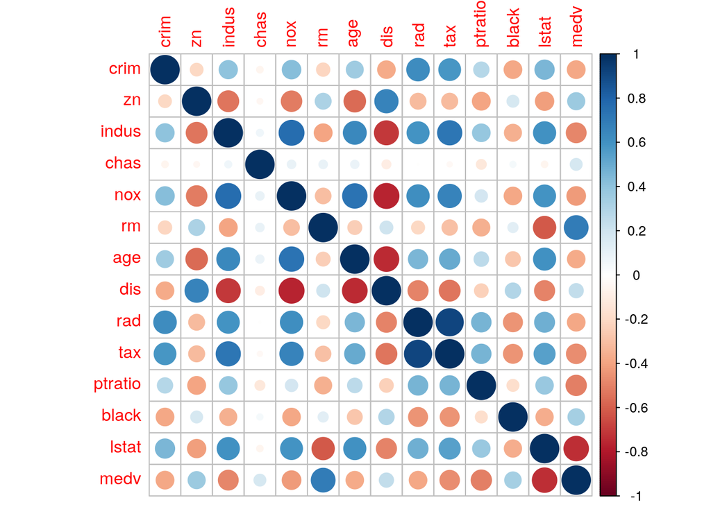

```r
corrplot(cor(Boston), method="circle")
```

## Data wrangling

Whew, that was a lot of text for simply exploring the data! Now I have to actually do something with it, so let’s get to it! First, the data needs to be standardized, which is done by subtracting the mean from the values and dividing by the standard deviation for each column. Now the data has a mean value of zero for each column! Also, the values are now “how many standard deviations away they are from the mean value” instead of actual values. However, the density functions’ form *did not* change, which is also what we want.

```r
scaled <- scale(Boston)

# scale() returns a matrix object, change it to a data.frame
scaled <- as.data.frame(scaled)
summary(scaled)
```

```
      crim                 zn               indus              chas
 Min.   :-0.419367   Min.   :-0.48724   Min.   :-1.5563   Min.   :-0.2723
 1st Qu.:-0.410563   1st Qu.:-0.48724   1st Qu.:-0.8668   1st Qu.:-0.2723
 Median :-0.390280   Median :-0.48724   Median :-0.2109   Median :-0.2723
 Mean   : 0.000000   Mean   : 0.00000   Mean   : 0.0000   Mean   : 0.0000
 3rd Qu.: 0.007389   3rd Qu.: 0.04872   3rd Qu.: 1.0150   3rd Qu.:-0.2723
 Max.   : 9.924110   Max.   : 3.80047   Max.   : 2.4202   Max.   : 3.6648
      nox                rm               age               dis
 Min.   :-1.4644   Min.   :-3.8764   Min.   :-2.3331   Min.   :-1.2658
 1st Qu.:-0.9121   1st Qu.:-0.5681   1st Qu.:-0.8366   1st Qu.:-0.8049
 Median :-0.1441   Median :-0.1084   Median : 0.3171   Median :-0.2790
 Mean   : 0.0000   Mean   : 0.0000   Mean   : 0.0000   Mean   : 0.0000
 3rd Qu.: 0.5981   3rd Qu.: 0.4823   3rd Qu.: 0.9059   3rd Qu.: 0.6617
 Max.   : 2.7296   Max.   : 3.5515   Max.   : 1.1164   Max.   : 3.9566
      rad               tax             ptratio            black
 Min.   :-0.9819   Min.   :-1.3127   Min.   :-2.7047   Min.   :-3.9033
 1st Qu.:-0.6373   1st Qu.:-0.7668   1st Qu.:-0.4876   1st Qu.: 0.2049
 Median :-0.5225   Median :-0.4642   Median : 0.2746   Median : 0.3808
 Mean   : 0.0000   Mean   : 0.0000   Mean   : 0.0000   Mean   : 0.0000
 3rd Qu.: 1.6596   3rd Qu.: 1.5294   3rd Qu.: 0.8058   3rd Qu.: 0.4332
 Max.   : 1.6596   Max.   : 1.7964   Max.   : 1.6372   Max.   : 0.4406
     lstat              medv
 Min.   :-1.5296   Min.   :-1.9063
 1st Qu.:-0.7986   1st Qu.:-0.5989
 Median :-0.1811   Median :-0.1449
 Mean   : 0.0000   Mean   : 0.0000
 3rd Qu.: 0.6024   3rd Qu.: 0.2683
 Max.   : 3.5453   Max.   : 2.9865
```

```r
longtable <- melt(scaled)
```

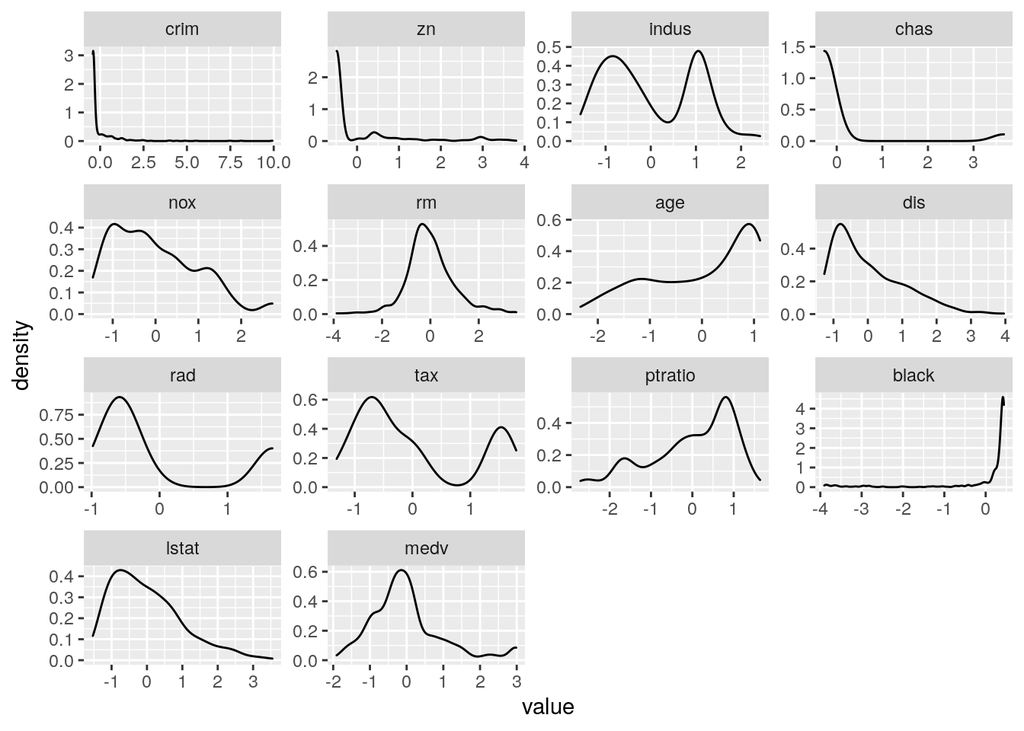

```r
ggplot(longtable, aes(value)) + geom_density() + facet_wrap(~variable, scales="free")
```

In this exercise, we’re trying to ultimately predict the crime rate using Linear Discriminant Analysis (LDA). To do this, we first create a categorical target variable for crime rate by dividing the data. Here we do this by cutting the data into four quantiles.

```r
# create a quantile vector of crim and print it
bins <- quantile(scaled$crim)
bins
```

```
          0%          25%          50%          75%         100%
-0.419366929 -0.410563278 -0.390280295  0.007389247  9.924109610
```

```r
# create a categorical variable 'crime' and take a look using table()
crime <- cut(scaled$crim, breaks = bins, include.lowest = TRUE, label=c("low", "med_low", "med_high", "high"))
table(crime)
```

```
crime
     low  med_low med_high     high
     127      126      126      127
```

```r
# remove original `crim` and add the new `crime` variable to the dataset
# Here I need to explicitly call dplyr::select, as MASS library also has a select function
scaled <- dplyr::select(scaled, -crim)
scaled <- data.frame(scaled, crime)
```

Next up, we’ll have to train and test the LDA model with our data. So, let’s split the data to training and testing datasets using a 80:20 split. Also, the test data shouldn’t contain the true labels so that we don’t confuse our model, but we need that information for verifying our model. So let’s store the labels into another object.

```r
# number of rows in the Boston dataset
n <- nrow(scaled)

# choose randomly 80% of the rows
ind <- sample(n,  size = n * 0.8)

# create train and test sets
train <- scaled[ind,]
test <- scaled[-ind,]  # note the minus!

# save the correct classes from test data
correct_classes_for_test <- test$crime

# remove the crime variable from test data
test <- dplyr::select(test, -crime)
```

## Linear Discriminant Analysis

Now that our data is in a suitable format, let’s get to business. Luckily, fitting the LDA is a one-liner. Here our target is `crime` and explanatory variables are everything else (denoted with `.`). Also, I shamelessly copied the biplot plotting code from Datacamp exercises (because programming it would be too difficult at this point). Let’s see what happens.

```r
lda.fit <- lda(crime ~ ., data = train)
lda.fit  # Just checking the output
```

```
Call:
lda(crime ~ ., data = train)

Prior probabilities of groups:
      low   med_low  med_high      high
0.2549505 0.2400990 0.2599010 0.2450495

Group means:
                 zn      indus        chas        nox         rm        age
low       0.9753697 -0.9434514 -0.08120770 -0.8837233  0.4325390 -0.9381520
med_low  -0.1157120 -0.2855907  0.01179157 -0.5543991 -0.1296850 -0.3048100
med_high -0.3631007  0.1961002  0.25261763  0.3994375  0.1537163  0.3898780
high     -0.4872402  1.0149946 -0.07348562  1.0385550 -0.3794012  0.8013618
                dis        rad        tax     ptratio       black       lstat
low       0.9342664 -0.6785867 -0.7383022 -0.44674754  0.37958778 -0.77846727
med_low   0.3208755 -0.5591880 -0.4598702 -0.04993701  0.31380803 -0.15663318
med_high -0.4035941 -0.4065439 -0.3123179 -0.43168810  0.09591388 -0.05170852
high     -0.8422717  1.6596029  1.5294129  0.80577843 -0.68079981  0.90402871
                medv
low       0.53480421
med_low  -0.02744276
med_high  0.24205894
high     -0.73842724

Coefficients of linear discriminants:
                LD1          LD2         LD3
zn       0.07214555  0.610195519 -0.85295795
indus    0.04785751 -0.409068774  0.13049624
chas    -0.08241604 -0.009705042  0.09797199
nox      0.22690421 -0.714147079 -1.42365374
rm      -0.09277179 -0.062028307 -0.11140387
age      0.26316698 -0.346412935  0.02425944
dis     -0.08409444 -0.147792348 -0.02421958
rad      3.41887302  0.670047867 -0.31331749
tax      0.01133046  0.319706540  0.70765000
ptratio  0.08939538  0.134648187 -0.18848405
black   -0.12840758 -0.012087855  0.07913283
lstat    0.22188192 -0.191386778  0.28940556
medv     0.19374414 -0.370964344 -0.30837420

Proportion of trace:
   LD1    LD2    LD3
0.9470 0.0412 0.0119
```

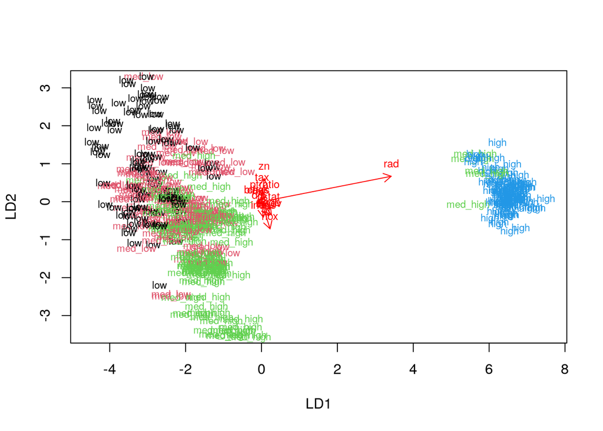

```r
# Function lifted directly from DataCamp exercises
# the function for lda biplot arrows
lda.arrows <- function(x, myscale = 1, arrow_heads = 0.1, color = "red", tex = 0.75, choices = c(1,2)){
  heads <- coef(x)
  arrows(x0 = 0, y0 = 0,
         x1 = myscale * heads[,choices[1]],
         y1 = myscale * heads[,choices[2]], col=color, length = arrow_heads)
  text(myscale * heads[,choices], labels = row.names(heads),
       cex = tex, col=color, pos=3)
}

# target classes as numeric
classes <- as.numeric(train$crime)

# plot the lda results
plot(lda.fit, dimen = 2, col=classes, pch=classes)
lda.arrows(lda.fit, myscale = 1)
```

So, what about our model’s predictions? Predict with test data and cross tabulate the predictions with the actual labels, got it!

```r
# predict classes with test data
lda.pred <- predict(lda.fit, newdata = test)
table(correct = correct_classes_for_test, predicted = lda.pred$class) %>% addmargins
```

```
          predicted
correct    low med_low med_high high Sum
  low       12       7        5    0  24
  med_low    8      17        4    0  29
  med_high   1      11        8    1  21
  high       0       0        1   27  28
  Sum       21      35       18   28 102
```

[output not shown]

## k-means Clustering

Finally, we’ll practice some clustering with the “clustering hello world algorithm”, also known as k-means clustering. Basically this algorithm creates *k* clusters by finding *k* points that minimize the mean distance between the “k-points” and the data points (though it’s not foolproof, the outcome depends on where the initial k-points are). Each data point is assigned to the nearest k-point, which forms the cluster.

Moving on, now that short (and probably a bit unnecessary) introduction is out of the way, I’ll reload the original `Boston` dataset and scale it once again for clustering.

```r
# Reload original Boston dataset
data('Boston')

# Scale the dataset
boston_scaled <- scale(Boston) %>% as.data.frame()
# I won't repeat the summary here, it's the same as shown previously...

# Calculate euclidean distance and show it
dist_eu <- dist(boston_scaled)
summary(dist_eu)
```

```
   Min. 1st Qu.  Median    Mean 3rd Qu.    Max.
 0.1343  3.4625  4.8241  4.9111  6.1863 14.3970
```

```r
# Let's calculate also manhattan distance for good measure
dist_man <- dist(boston_scaled, method="manhattan")
summary(dist_man)
```

```
   Min. 1st Qu.  Median    Mean 3rd Qu.    Max.
 0.2662  8.4832 12.6090 13.5488 17.7568 48.8618
```

Okay, next up is the actual clustering. Let’s start with three k-points and see the result.

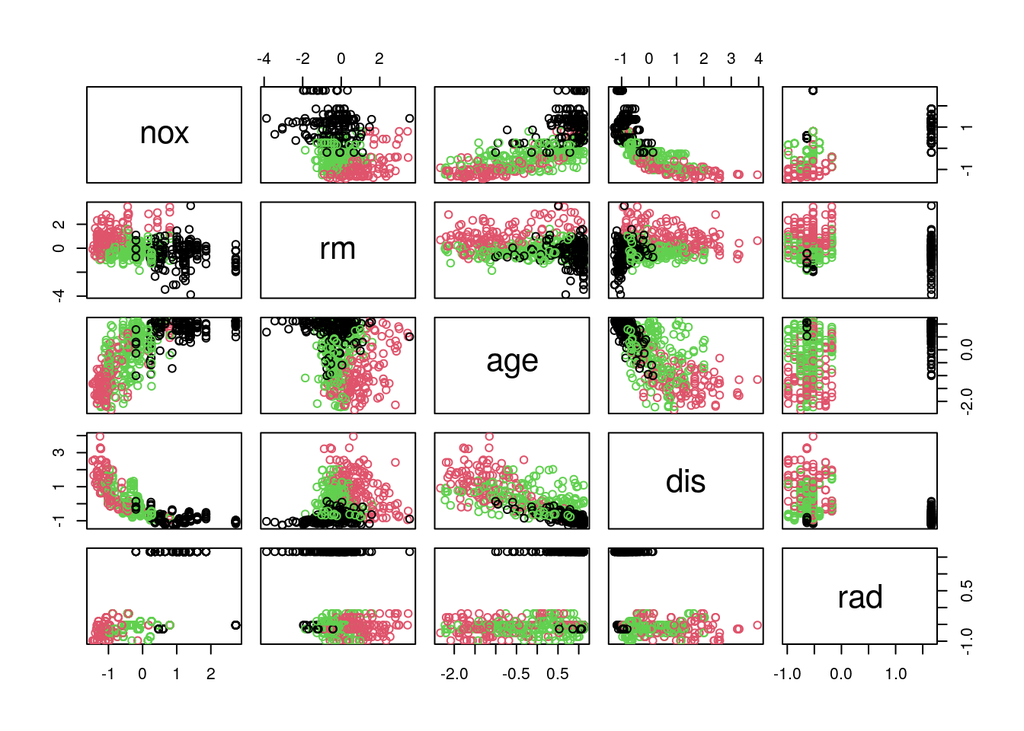

```r
km <-kmeans(boston_scaled, centers = 3)
# Plot a subset of boston_scaled data with clusters colored, just to see how it looks like
pairs(boston_scaled[5:9], col = km$cluster)
```

I don’t know whose idea it was to have black, *red* and *green* as the three first default colors in R… I just hope that these shades of red and green are distinct enough for (red-green) colorblind people are able to tell the difference. And wow, the clusters swap colors when I replot the figure! Yeah, I really have to learn the `ggplot2` library by heart if I’m ever going to use R outside this course. But I digress. Moving on…

Multiple methods for figuring out the optimal value for *k* exist, but here we use a metric called *total of within cluster sum of squares* (WCSS). The optimal number for k is where the WCSS has a *radical* drop! The `kmeans` function returns an object that handily provides the WCSS value in `tot.withinss` component. The DataCamp exercises graciously include an one-liner to calculate WCSS for the data using `k=1...k_max`, so I’m totally going to use that one! Let’s set `k_max` to 10 to limit the iterations a bit and then we’ll look for the optimal value visually - i.e by plotting `WCSS(k)`.

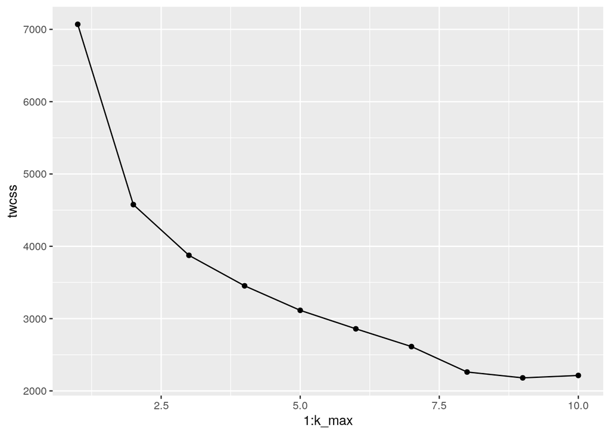

```r
# Maximum number of clusters considered here
k_max <- 10

# This one is also copied from DataCamp...
# calculate the total within sum of squares
twcss <- sapply(1:k_max, function(k){kmeans(boston_scaled, k)$tot.withinss})

# Visualise!
qplot(x = 1:k_max, y = twcss, geom = c('line', 'point'))
```

The most *radical* decrease would be from going `k=1` to `k=2`, so the value 2 seems to be a great candidate. Though the WCSS values drop up to `k=9`, so something like 5 or 7 might be potential candidates. But 2 makes it so that there will be only two colors in the up-coming plots, making them a bit easier to interpret. So I’ll use `k=2`.[^1]

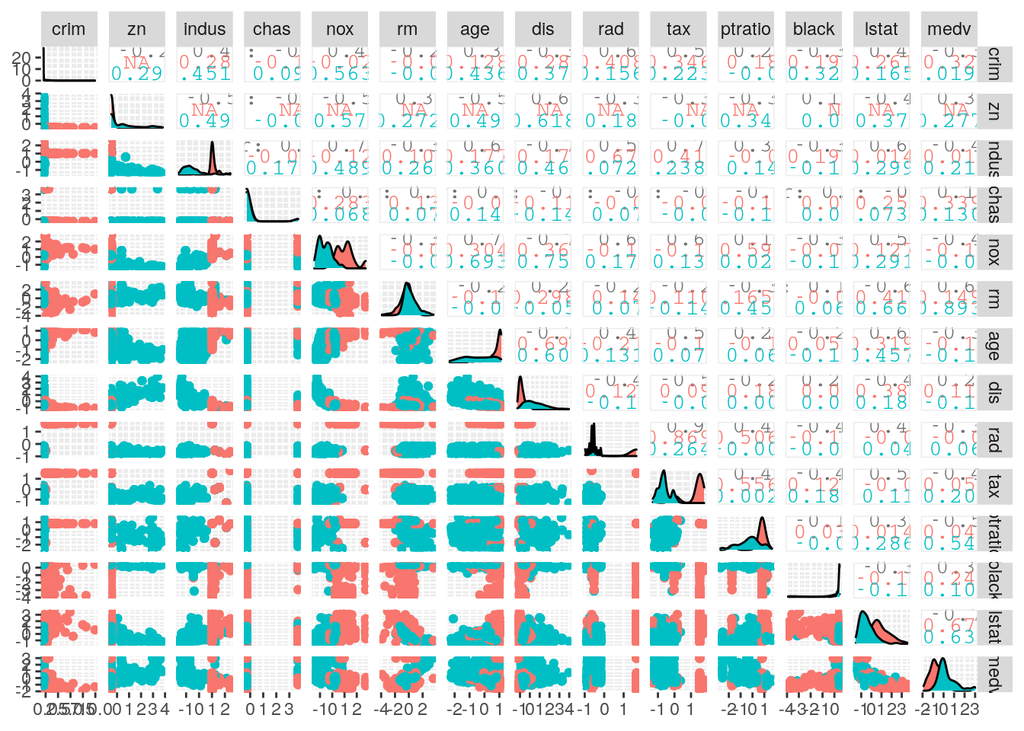

```r
# Re-cluster the data
km <-kmeans(boston_scaled, centers = 2)
#
# plot the Boston dataset with clusters
# This time the full dataset with ggpairs -- it's stil going to be a mess, but it'll be a pretty mess.
ggpairs(boston_scaled, aes(col=as.factor(km$cluster)))
```

```r
# This chunk emits a bunch of "Warning in cor(x, y): the standard deviation is zero" warning messages.
```

Yep, that’s a pretty looking mess. Also that chunk emits a bunch of `Warning in cor(x, y): the standard deviation is zero` warning messages (I’ve omitted those as they’re wasting space). Looks like the correlations for `zn` in the red class are `NA`, so that’s probably where the standard deviation is zero. Anyways, let’s first plot the density plots like before, and then check only a handful of variables with larger pictures.

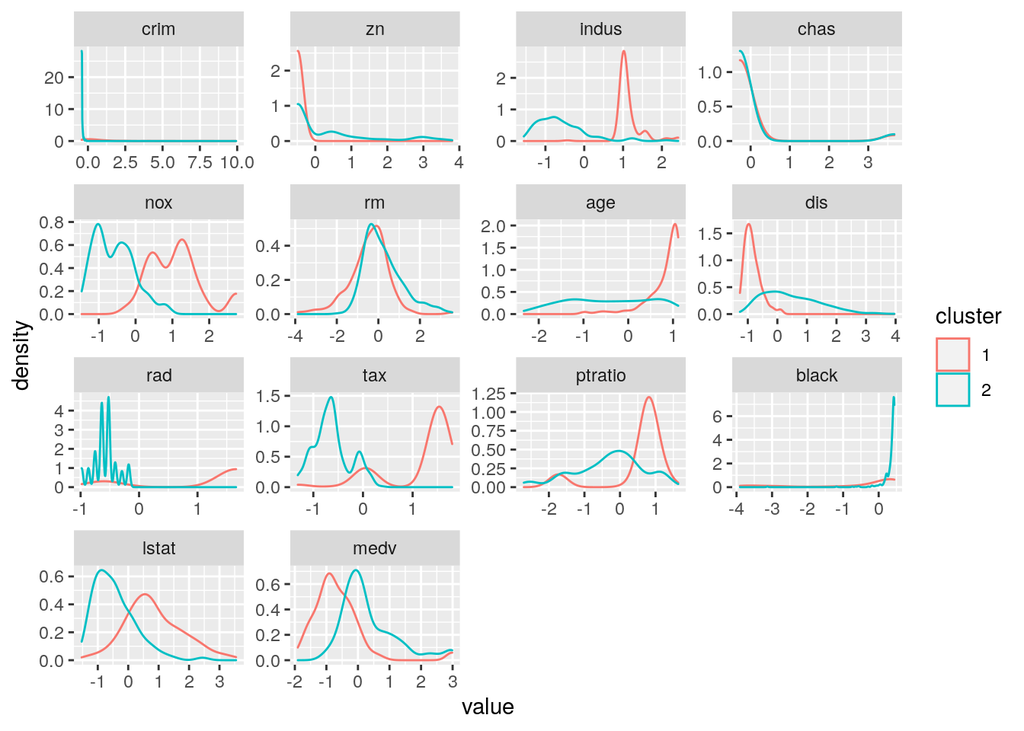

```r
with_colors <- boston_scaled
with_colors$cluster <- as.factor(km$cluster)
longtable <- melt(with_colors)
ggplot(longtable, aes(value, col=cluster)) + geom_density() + facet_wrap(~variable, scales="free")
```

Well, that’s interesting! Some of the variables now show two differing density curves – essentially meaning that there could be a way to separate the data into two different groups. If you recall my pondering from the data exploration, I noted that `indus`, `rad` and `tax` variables show two peaks – well, the two peaks seem to belong into different clusters! However, what I couldn’t see before, was that also `age`, `dis`, `ptratio`, and arguably `lstat` and `medv`, would be a combination of two different (and separable) curves. `nox` being also very separable is not a surprise (in hindsight), when you already know that industrial zones cause more pollution than residential zones (typically).

Let’s pick some variables that look interesting.

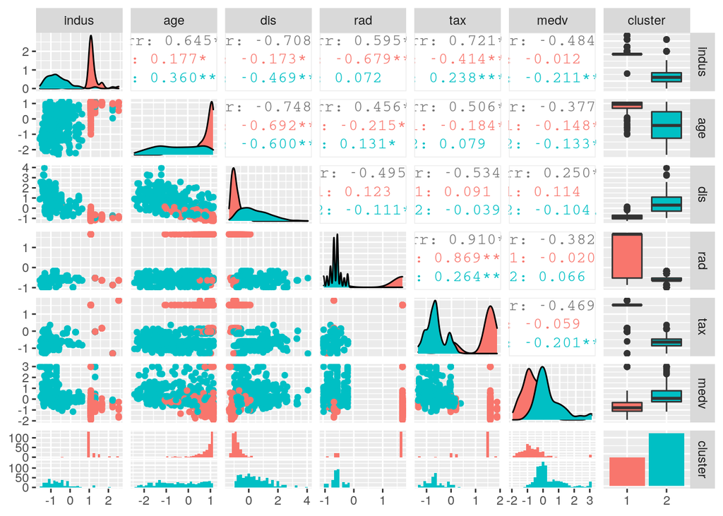

```r
#with_colors <- boston_scaled
#with_colors$cluster <- as.factor(km$cluster)
subset <- dplyr::select(with_colors, c("indus", "age", "dis", "rad", "tax", "medv", "cluster"))
#subset$cluster <- as.factor(subset$cluster)
ggpairs(subset, aes(col=cluster))
```

Well, they look interesting. For example, `tax` looks to be separated quite nicely, same with `dis` and `age`. Old people live close to the industrial employment centers and pay more in taxes? That would be one plausible conclusion from this data.

## Bonus task

Surprise! There are two bonus tasks for this week! There were some also for the last week, but I didn’t do those. But it’s getting a bit late, so this’ll have to be short. The first one is to fit LDA for some number of clusters (>2). I chose 7. For that, the most influential variables seem to be `chas` and `rad`. The second bonus task, well, I can’t manage everything.

```r
# Reload original Boston dataset
data('Boston')

# Scale the dataset
bonus_scaled <- scale(Boston) %>% as.data.frame
summary(bonus_scaled)
```

```
      crim                 zn               indus              chas
 Min.   :-0.419367   Min.   :-0.48724   Min.   :-1.5563   Min.   :-0.2723
 1st Qu.:-0.410563   1st Qu.:-0.48724   1st Qu.:-0.8668   1st Qu.:-0.2723
 Median :-0.390280   Median :-0.48724   Median :-0.2109   Median :-0.2723
 Mean   : 0.000000   Mean   : 0.00000   Mean   : 0.0000   Mean   : 0.0000
 3rd Qu.: 0.007389   3rd Qu.: 0.04872   3rd Qu.: 1.0150   3rd Qu.:-0.2723
 Max.   : 9.924110   Max.   : 3.80047   Max.   : 2.4202   Max.   : 3.6648
      nox                rm               age               dis
 Min.   :-1.4644   Min.   :-3.8764   Min.   :-2.3331   Min.   :-1.2658
 1st Qu.:-0.9121   1st Qu.:-0.5681   1st Qu.:-0.8366   1st Qu.:-0.8049
 Median :-0.1441   Median :-0.1084   Median : 0.3171   Median :-0.2790
 Mean   : 0.0000   Mean   : 0.0000   Mean   : 0.0000   Mean   : 0.0000
 3rd Qu.: 0.5981   3rd Qu.: 0.4823   3rd Qu.: 0.9059   3rd Qu.: 0.6617
 Max.   : 2.7296   Max.   : 3.5515   Max.   : 1.1164   Max.   : 3.9566
      rad               tax             ptratio            black
 Min.   :-0.9819   Min.   :-1.3127   Min.   :-2.7047   Min.   :-3.9033
 1st Qu.:-0.6373   1st Qu.:-0.7668   1st Qu.:-0.4876   1st Qu.: 0.2049
 Median :-0.5225   Median :-0.4642   Median : 0.2746   Median : 0.3808
 Mean   : 0.0000   Mean   : 0.0000   Mean   : 0.0000   Mean   : 0.0000
 3rd Qu.: 1.6596   3rd Qu.: 1.5294   3rd Qu.: 0.8058   3rd Qu.: 0.4332
 Max.   : 1.6596   Max.   : 1.7964   Max.   : 1.6372   Max.   : 0.4406
     lstat              medv
 Min.   :-1.5296   Min.   :-1.9063
 1st Qu.:-0.7986   1st Qu.:-0.5989
 Median :-0.1811   Median :-0.1449
 Mean   : 0.0000   Mean   : 0.0000
 3rd Qu.: 0.6024   3rd Qu.: 0.2683
 Max.   : 3.5453   Max.   : 2.9865
```

```r
# k-means clustering with 7 clusters
km <-kmeans(bonus_scaled, centers = 7)
summary(km)
```

```
             Length Class  Mode
cluster      506    -none- numeric
centers       98    -none- numeric
totss          1    -none- numeric
withinss       7    -none- numeric
tot.withinss   1    -none- numeric
betweenss      1    -none- numeric
size           7    -none- numeric
iter           1    -none- numeric
ifault         1    -none- numeric
```

```r
# Add clusters to dataset
bonus_scaled$cluster <- km$cluster

# LDA fit targetting clusters
lda.fit <- lda(cluster ~ ., data = bonus_scaled)
lda.fit  # Just checking the output
```

```
Call:
lda(cluster ~ ., data = bonus_scaled)

Prior probabilities of groups:
         1          2          3          4          5          6          7
0.09683794 0.09288538 0.06916996 0.15415020 0.17588933 0.34387352 0.06719368

Group means:
        crim         zn      indus       chas        nox         rm         age
1 -0.3774003 -0.1398479 -0.8703728 -0.2723291 -0.2390554  1.5399833  0.07933756
2 -0.2834643 -0.4872402  1.5965043 -0.2723291  1.0453673 -0.6245590  0.94375129
3  1.4802645 -0.4872402  1.0149946 -0.2723291  0.9676887 -0.2969389  0.76560159
4 -0.4126954  1.9952361 -1.1032525 -0.2218534 -1.1552982  0.6080657 -1.40363754
5  0.9722616 -0.4872402  1.0149946 -0.2723291  1.0010692 -0.4790990  0.74608713
6 -0.3884148 -0.3253420 -0.4696145 -0.2723291 -0.4787024 -0.2866326 -0.25638178
7 -0.1985497 -0.2602436  0.2799956  3.6647712  0.3830784  0.2756681  0.37213224
         dis          rad         tax    ptratio       black      lstat
1 -0.2868574 -0.520140581 -0.82627237 -1.0314738  0.35523433 -0.9636997
2 -0.8963217 -0.622669809  0.03772813 -0.2084479 -0.08717824  0.7185475
3 -0.8580043  1.659602895  1.52941294  0.8057784 -3.29705640  1.1699052
4  1.5772490 -0.627024335 -0.57588304 -0.7161406  0.35335146 -0.9028481
5 -0.8009959  1.659602895  1.52941294  0.8057784  0.16590165  0.8119640
6  0.2769540 -0.587168164 -0.59021294  0.1702603  0.30993538 -0.1365045
7 -0.4033382  0.001081444 -0.09756330 -0.3924585  0.17154271 -0.1643525
        medv
1  1.6147330
2 -0.5152915
3 -1.0473739
4  0.6621944
5 -0.6627877
6 -0.1747229
7  0.5733409

Coefficients of linear discriminants:
                 LD1         LD2          LD3         LD4         LD5
crim    -0.032848874 -0.11853833 -0.121992191 -0.04587015  0.02028959
zn      -0.236386535 -0.11164525 -0.892168260  0.07752273 -1.47340439
indus    0.122244436 -0.61676862  1.373115707 -0.29017671 -1.77461828
chas     5.826738406  0.17279307 -0.348402443 -0.10993258 -0.06074649
nox      0.007038657  0.41797220  0.349383719  0.25040677 -0.36306581
```

[output cut: 13 more lines]

```
chas     0.27933856
nox     -0.44219930
rm      -0.56819492
age     -0.24907323
dis      0.14176355
rad     -0.05116781
tax      0.20960416
ptratio  0.32614059
black    0.01111638
lstat   -0.25238312
medv    -0.88020068

Proportion of trace:
   LD1    LD2    LD3    LD4    LD5    LD6
0.5738 0.2535 0.0673 0.0566 0.0353 0.0134
```

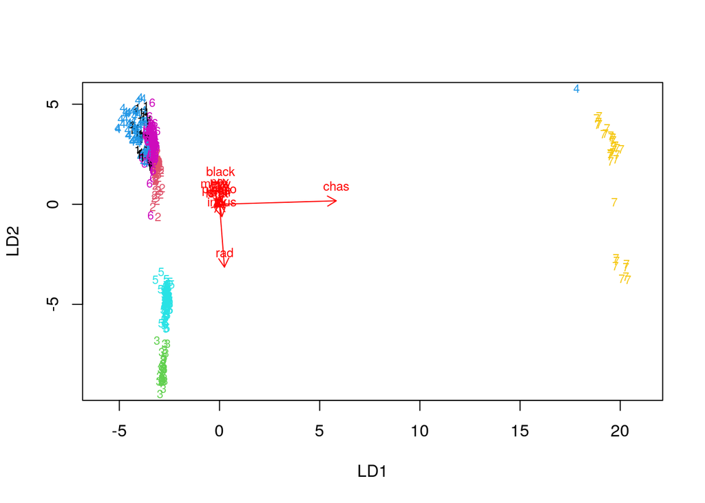

```r
# target classes as numeric
classes <- as.numeric(bonus_scaled$cluster)

# plot the lda results
plot(lda.fit, dimen = 2, col=classes, pch=classes)
lda.arrows(lda.fit, myscale = 1)
```

[^1]: I also got `k=3` as optimal value when I accidentally ran the code without setting seed beforehand. Whoops. Well, like I said, the results of k-means depend on the initial (random) points.